# Assignment 04 - College Data Analysis

tony sulfaro

4/29/2019

# Data Background

The college data `college_all_ages` comes from the package `fivethrityeight` as a dataset included by default when installed. The data contained within the dataset originally came from an American Community Survey 2010-2012 Public Use Microdata Series. This survey was put out by the United State Census Bureau. The data was collected to help give insight into the compensation and unemployment rates for graduates of higher-level education. This data can help us answer questions about which majors have the highest and lowest compensation rates as well as how unemployment rates compare between major categories.

# Data Characteristics

There are 173 entries in the `college_all_ages` dataset with 11 variables. An observation in this dataset is a specific major and the attributes that go along with it (like the number of people with that degree and median compensation for their field).

The data includes fields like major name, the major category it resides in (eg: Business), and some other numeric values like how many people are employed in that field, how many are unemployed, what the median salary is for that major in USD, etc.

# Variation in Compensation and Total Employed

To help us understand what kind of categories there are and how much compensation varies within those categories, let’s take a look at a boxplot with major categories and total compensation.

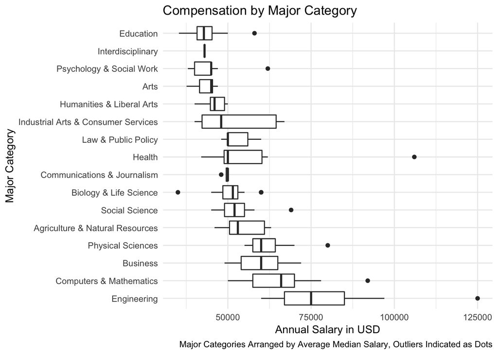

After generating the boxplot and arranging the major categories by average median salary we can see how much some of the categories vary. To get the median salary of each major category I added another variable using the mutate command to select the median salary for each major category within the dataset.

Health appears to have a huge range of salaries, mostly due to an outlier at 100k+. Engineering and Industrial Arts & Consumer Services, however, have the widest boxes, indicating that there are multiple majors within that category in that compensation range instead of just one.

However, Some of the boxplots look pretty strange, “Interdisciplinary” is just a line which isn’t very helpful when trying to estimate salary ranges. Looking at the data a different way may be able to explain why that it is like that.

### Total People In Each Category

In addition to salary by major category let’s take a look at the number of people in each major category as well as full-time employment in the form of a barplot.

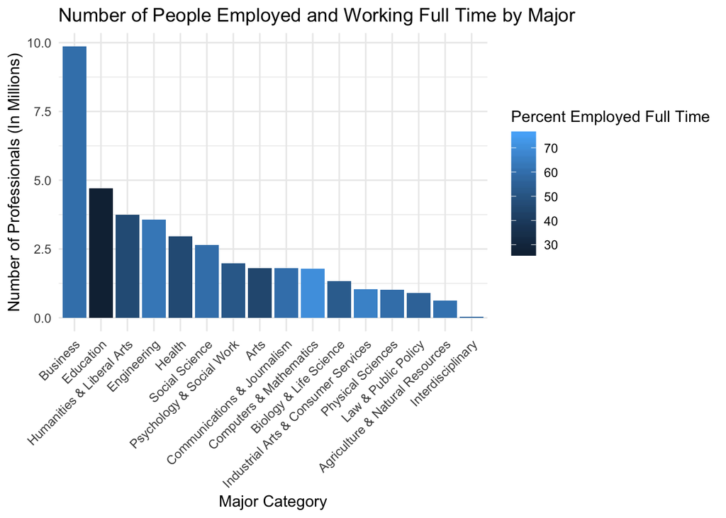

After generating a bar graph for each major category where the number of people in each category represent bar length and fill represents full-time employment there were some interesting results. To get this information I took the total amount of people in each major category and divided by one million to adjust the y-axis values and then calculated the percent employed fulltime as a number from 0 to 100.

From the graph, business is by far the most popular major category with education coming in second at less than half the amount of business. What was also interesting was how low fulltime employment was for education majors. This makes sense because many teachers do not each at least 50 weeks out of the year because of summer and winter breaks in schooling.

# Relationships Between Variables

To help us identify trends between variables we can use `ggpairs()` to plot multiple variables against one another and obtain their r value. The r value is a number that ranges from -1.0 to 1.0 that indicates how linearly two variables correlate to one another, (-1 meaning complete negative correlation, 1 meaining complete positive correlation).

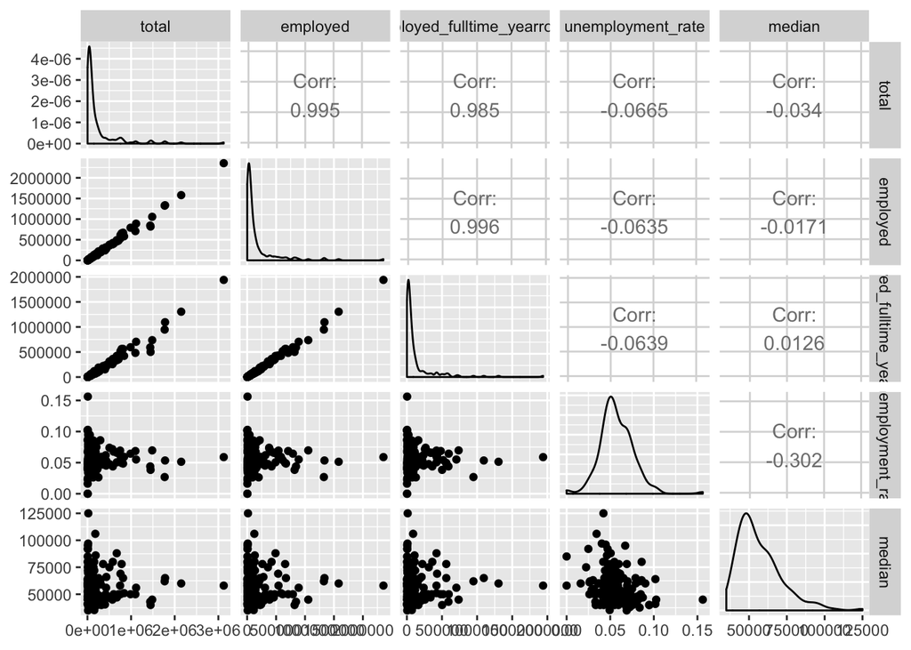

After looking through the various combinations of variable scatter plots I want to know a bit more about the correlation between median compensation and unemployment rate. Let’s construct a scatterplot with a trend line on top to verify this information.

### Median Compensation vs Unemployment Rate

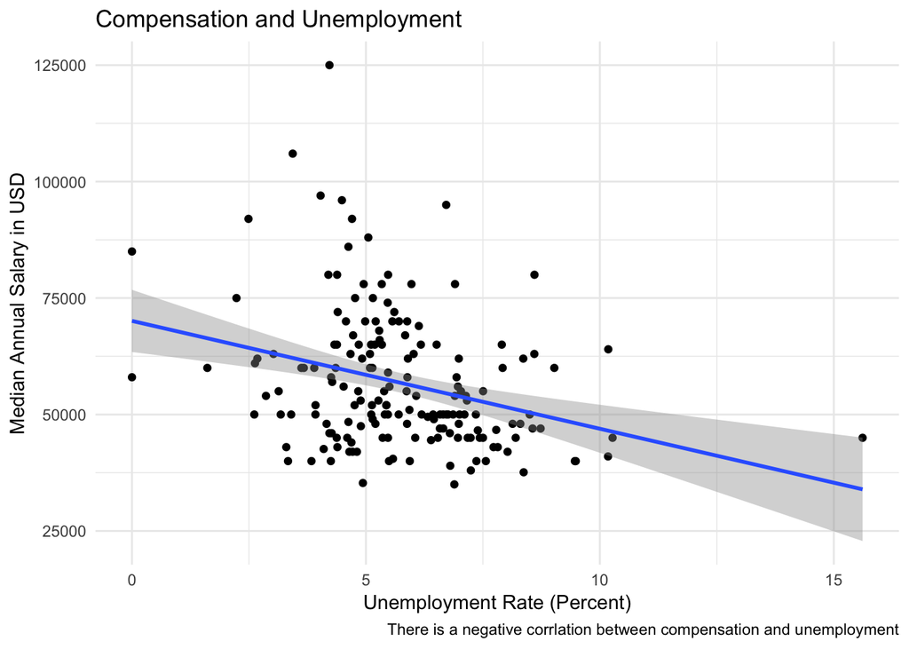

There seems to be a negative correlation between average compensation and unemployment rate. The less a particular field pays, the more likely the field is to have individuals unemployed.

## Compensation by Major Category

To help see compensation and unemployment rate by profession let’s construct a barplot for each major category and compare their compensation and unemployment levels compared to one another. From the major categories, the median value for unemployment was taken instead of a mean to prevent outliers from skewing results.

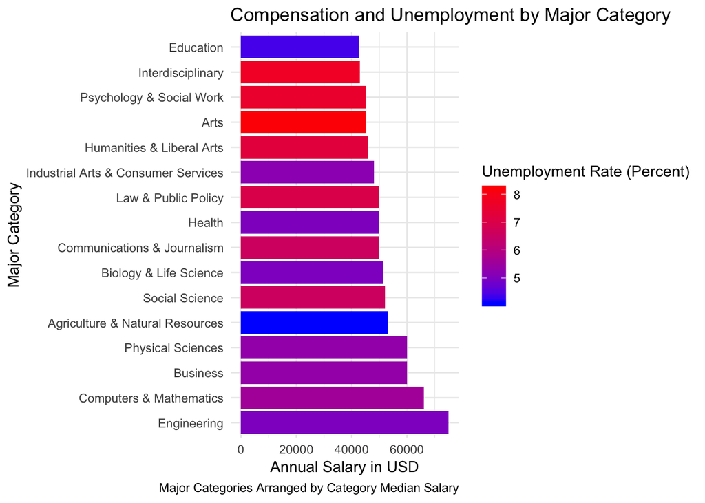

The negative correlation between salary and unemployment rate is shown in that the higher the compensation, the lower the unemployment rate tends to be. Some interesting exceptions to this trend appear to be “Education” and “Agriculture & Natural Resources” which have the lowest unemployment rates out of the entire dataset and have different median compensation values.